# Lecture 6: Other Sequence Objects

- Lists are one specific kind of "sequence" object in Python.
- Two others are `tuples` and `strings` (we've seen strings already)

We'll make a list of 4 elements, then create an equivalent tuple

```python
list_of_numbers = [5, 3, 2, 0]

tuple_of_numbers = (5, 3, 2, 0)

print(list_of_numbers)
print(tuple_of_numbers)
print()
print(type(list_of_numbers))
print(type(tuple_of_numbers))
```

```
[5, 3, 2, 0]
(5, 3, 2, 0)

<class 'list'>
<class 'tuple'>
```

Lists are **mutable**. This means we can change them or "mutate" them

```python
list_of_numbers[3] = 55
print(list_of_numbers)
```

```
[5, 3, 2, 55]
```

Tuples are **immutable**. We cannot change them once they are created.

This is a good place to store values if you *know* they should never be changed.

```python
# Can access elements of tuple just list lists
print(tuple_of_numbers[3])
```

```
0
```

```python
# But we cannot modify them!
tuple_of_numbers[3] = 55
```

```
---------------------------------------------------------------------------
TypeError                                 Traceback (most recent call last)
Cell In[4], line 2
      1 # But we cannot modify them!
----> 2 tuple_of_numbers[3] = 55

TypeError: 'tuple' object does not support item assignment
```

Strangely enough, you can create tuples without typing the parentheses explicitly...

```python
tuple_of_numbers = 5, 3, 2, 0

print(tuple_of_numbers)
print()
print(type(tuple_of_numbers))
```

```
(5, 3, 2, 0)

<class 'tuple'>
```

**Strings** are similar to tuples, but they are sequences of **characters**

```python
my_name = "Peter Sentz"

print(type(my_name))
print(len(my_name))
print()
print(my_name[0]) # Character zero of string (a capital "P")
print(my_name[4]) # Character four of string (lowercase "r")
print(my_name[5]) # Character five of string (white space)
print(my_name[6]) # Character six of string (capital "S")
print(my_name[10]) # Character ten of string (lowercase "z")

# next line will cause an error
# print(my_name[11]) # there is no Character 11
```

```
<class 'str'>
11

P
r

S
z
```

```python
# A similar error occurs when using too large
# of an index for tuples and lists
print(tuple_of_numbers[5])
```

```
---------------------------------------------------------------------------
IndexError                                Traceback (most recent call last)
Cell In[7], line 3
      1 # A similar error occurs when using too large
      2 # of an index for tuples and lists
----> 3 print(tuple_of_numbers[5])

IndexError: tuple index out of range
```

Strings are **immutable!** They cannot be changed after being defined.

```python
my_name[0] = "p"
```

```
---------------------------------------------------------------------------
TypeError                                 Traceback (most recent call last)
Cell In[8], line 1
----> 1 my_name[0] = "p"

TypeError: 'str' object does not support item assignment
```

## Concatenation

The "+" operator can be used to **concatenate** lists, strings, or tuples.

```python
list_1 = [2, 3, 5, 11]
list_2 = [1, -4, 2, 0]

list_3 = list_1 + list_2

print(list_3)
```

```
[2, 3, 5, 11, 1, -4, 2, 0]
```

```python
first_name = "Peter"
last_name = "Sentz"
my_name = first_name + last_name
print(my_name)

# How do I make it so there's a space in between?
```

```
PeterSentz
```

```python
# method 1 - Add white space at end of first_name
first_name = "Peter "
last_name = "Sentz"
my_name = first_name + last_name
print(my_name)

# method 2 - Add white space at beginning of last_name
first_name = "Peter"
last_name = " Sentz"
my_name = first_name + last_name
print(my_name)
```

```
Peter Sentz
Peter Sentz
```

```python
tuple_1 = (1, 2, 0, 9, 8)
tuple_2 = (-1, -50)

print(tuple_1 + tuple_2)
```

```
(1, 2, 0, 9, 8, -1, -50)
```

Don't need to create variables before concatenating...

```python
my_list = ["sequence", "Python", 1.2, 0] + [5, -3]
print(my_list)

my_name = "Peter" + " " + "T." + " " + "Sentz" + "!"
print(my_name)

# Do we need comma after the 1?
my_tuple = (1,) + (2, 3, 4, 5, 6, 7, 8, 9)
print(my_tuple)
```

```
['sequence', 'Python', 1.2, 0, 5, -3]
Peter T. Sentz!
(1, 2, 3, 4, 5, 6, 7, 8, 9)
```

```python
# Yes, we need the comma after the 1!

my_tuple = (1) + (2, 3, 4, 5, 6, 7, 8, 9)
print(my_tuple)
```

```
---------------------------------------------------------------------------
TypeError                                 Traceback (most recent call last)
Cell In[14], line 3
      1 # Yes, we need the comma after the 1!
----> 3 my_tuple = (1) + (2, 3, 4, 5, 6, 7, 8, 9)
      4 print(my_tuple)

TypeError: unsupported operand type(s) for +: 'int' and 'tuple'
```

```python
# Explanation

print(type(1)) # this is an integer
print(type((1,))) # this is a tuple
```

```
<class 'int'>
<class 'tuple'>
```

```python
# Commas are more important than the parentheses for tuples
my_tuple = 1, + 2, 3, 4, 5, 6, 7, 8, 9
print(my_tuple)
```

```
(1, 2, 3, 4, 5, 6, 7, 8, 9)
```

```python
# Affect of parentheses/brackets/commas when defining an object
var_1 = 1
var_2 = (1)
var_3 = (1,)
var_4 = 1,
var_5 = [1]
var_6 = [1,]

print(type(var_1))
print(type(var_2))
print(type(var_3))
print(type(var_4))
print(type(var_5))
print(type(var_6))
```

```
<class 'int'>
<class 'int'>
<class 'tuple'>
<class 'tuple'>
<class 'list'>
<class 'list'>
```

# **Warning**

### If you try to create a new variable using the assignment operator with the **entire** list, it will not make a distinct copy! They will be two different names for the same object!

### This next cell shouldn't be very surprising...

```python
# we'll make a list where each entry is a floating-point number
list_of_floats = [2.3, -1.0, 5.1, 9.9]

# Here, we are grabbing *one* element of the list, so a new variable is made
new_variable = list_of_floats[2]

print("new_variable:", new_variable)

list_of_floats[2] = 0.0

print("list_of_floats:", list_of_floats)
print("new_variable:", new_variable)
```

```
new_variable: 5.1
list_of_floats: [2.3, -1.0, 0.0, 9.9]
new_variable: 5.1
```

### But the behavior of this next cell is a little surprising at first

```python
list_of_floats = [2.3, -1.0, 5.1, 9.9]

# Here, we are using the *entire list* with the assignment operator,
# so we are NOT making a distinct new variable

list_of_numbers = list_of_floats

print("list_of_numbers:", list_of_numbers)

list_of_floats[2] = 0.0

print("list_of_numbers:", list_of_numbers)
```

```
list_of_numbers: [2.3, -1.0, 5.1, 9.9]
list_of_numbers: [2.3, -1.0, 0.0, 9.9]
```

# Visualization with Lists

- Lists are useful when creating plots and other figures.
- Plots require multiple pieces of information (i.e. values or variables), so it is convenient to collect them in a single location.

There are 99 students registered for this course:

- 22 Freshmen
- 21 Sophomores
- 31 Juniors
- 25 Seniors

```python
import matplotlib.pyplot as plt
help(plt.bar)
```

[output not shown]

[output cut: 130 more lines]

[output not shown]

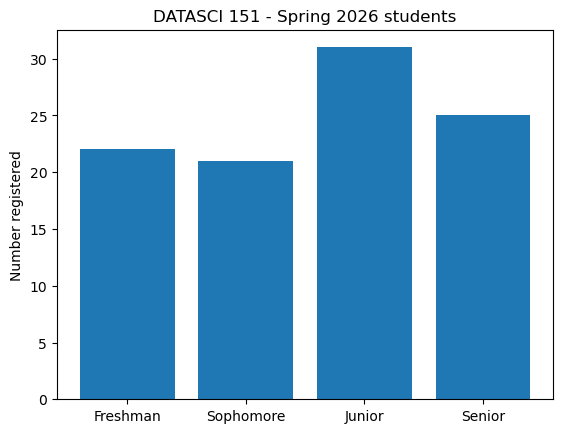

```python
# create bar plot here

categories = ["Freshman", "Sophomore", "Junior", "Senior"]
num_students = [22, 21, 31, 25]

plt.bar(x = categories, height = num_students)
plt.ylabel("Number registered")
plt.title("DATASCI 151 - Spring 2026 students")
plt.show()
```

# NumPy Arrays

- We saw that the "+" operator *concatenates* (or combines) two lists. This is also true for other sequence objects, like tuples and strings.
- What if we actually want to add the elements in two sequences entry by entry? We can do this using **NumPy** arrays.
- The NumPy library (NUMerical PYthon) is a library that is widely used for numerical computations (computations with floating-point numbers)
- It comes with a bunch of mathematical functions - **it basically makes the "math" library obsolete**
- It also comes with its own sequence object, the NumPy array

```python
# import the library. "np" is the standard nickname
import numpy as np

# The most common way to create a Numpy array is to convert a list
# into a numpy array.

list_of_numbers = [5.6, 2.9, 9.7, -10, 0, 3]

array_of_numbers = np.array(list_of_numbers)

print(type(array_of_numbers))
print(array_of_numbers)
display(array_of_numbers)
```

```
<class 'numpy.ndarray'>
[  5.6   2.9   9.7 -10.    0.    3. ]
```

```
array([  5.6,   2.9,   9.7, -10. ,   0. ,   3. ])
```

```python
# Usually, we would create the numpy array in a single line, without
# defining a separate list first

array_of_numbers = np.array([5.6, 2.9, 9.7, -10, 0, 3])


# you can access elements of arrays in the same way as lists:
print(array_of_numbers[0])
print(array_of_numbers[4])
```

```
5.6
0.0
```

- NumPy arrays are primarily useful for storing numbers. You *can* make a NumPy array with strings or other objects, but that is unusual.
- One of the benefits of NumPy is that all operations on arrays are numerical, unlike lists

```python
list_1 = [2, 3, 5, 11]
list_2 = [1, -4, 2, 0]

# The "+" operation concatenates the lists
print(list_1 + list_2)
```

```
[2, 3, 5, 11, 1, -4, 2, 0]
```

```python
array_1 = np.array([2, 3, 5, 11])
array_2 = np.array([1, -4, 2, 0])

# The "+" operation adds the elements of the two arrays together
print(array_1 + array_2)
```

```
[ 3 -1  7 11]
```

### The + operation performs element-by-element addition between two arrays of the **same size**. Mathematically, we view NumPy arrays as *vectors*, specifically column vectors.

$\text{An example where both arrays/vectors have 4 elements}$

$ a + b = \begin{pmatrix} a_1 \\ a_2 \\ a_3 \\ a_4 \end{pmatrix} + \begin{pmatrix} b_1 \\ b_2 \\ b_3 \\ b_4 \end{pmatrix} = \begin{pmatrix} a_1 + b_1 \\ a_2 + b_2 \\ a_3 + b_3 \\ a_4 + b_4 \end{pmatrix}$

### You can also use the "+" operator with a Numpy Array and a single number

$\text{For example:}$

$ a + 2 = \begin{pmatrix} a_1 \\ a_2 \\ a_3\end{pmatrix} + 2 = \begin{pmatrix} a_1 + 2 \\ a_2 + 2 \\ a_3 + 2\end{pmatrix}$

```python
# example

a = np.array([3, 11, -2.2])
print(a + 2)
```

```
[ 5.  13.  -0.2]
```

### We'll see below that this definition extends to other operations like subtraction, multiplication, division, exponentiation.

# Mathematical Constants and Operations

The usual mathematical operations - addition, subtraction, multiplication, division, and exponentiation are standard in Python.

In the cell below, we compute

- $3.2 + 1.7 = 4.9$
- $5 - 11 = -6$
- $4 \cdot 3 = 12$
- $\dfrac{1}{7} \approx 0.142857$
- $2^5 = 32$

```python
print(3.2 + 1.7)
print(5 - 11)
print(4 * 3)
print(1 / 7)
print(2**5)
```

```
4.9
-6
12
0.14285714285714285
32
```

**Be careful with order of operations** (also known as operator precedence)

How should we calculate the following in Python? $$ \frac{13 + 8}{3} = \frac{21}{3} = 7$$

```python
right_answer = (13 + 8) / 3
wrong_answer = 13 + 8 / 3
print(right_answer)
print(wrong_answer)
```

```
7.0
15.666666666666666
```

Numpy comes with a wide variety of mathematical constants and functions

Below, we will evaluate the following functions:

$$ \ln(x),\ \mathrm{e}^x,\ \sin(x),\ \cos(x),\ \sqrt{x}$$

```python
# log(x) computes the logarithm with base "e" (Euler's number)
    # in high school you might have called this ln(x)

# exp(x) compute Euler's number raised to the power of "x"

# sin(x) computes the sine of x (in radians)

# cos(x) computes the cosine of x (in radians)

# In this example, we're substituting x = 2

print(np.log(2))
print(np.exp(2))
print(np.sin(2))
print(np.cos(2))
print(np.sqrt(2))
```

```
0.6931471805599453
7.38905609893065
0.9092974268256817
-0.4161468365471424
1.4142135623730951
```

```python
# use variable instead of "2" when using the function

my_var = 2

print(np.log(my_var))
print(np.exp(my_var))
print(np.sin(my_var))
print(np.cos(my_var))
print(np.sqrt(my_var))
```

```
0.6931471805599453
7.38905609893065
0.9092974268256817
-0.4161468365471424
1.4142135623730951
```

```python
# NumPy also comes with built-in constants like
print(np.pi) # pi = circle's circumference/circle's diameter

print(np.e) # Euler's number = limit of (1 + 1/n)^n as n goes to infinity

print(np.exp(1)) # another way to calculate Euler's number
```

```
3.141592653589793
2.718281828459045
2.718281828459045
```

# Plotting functions using NumPy arrays

- NumPy arrays are very convenient for plotting functions, because you can use them within mathematical expressions as if they were numbers
- For example, suppose we want to create a scatter plot of the function

$$ f(x) = x^3 - 2x + \frac{1}{2} $$ at equally spaced points over the interval $-1.5 \leq x \leq 1.5$.

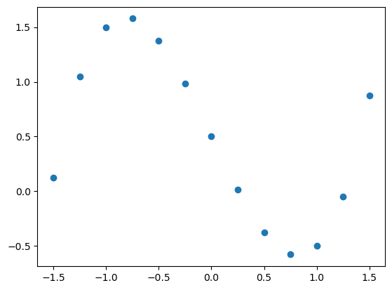

```python
# Create list of equally spaced points from -1.5 to 1.5
# We'll choose points 0.25 apart
x_vals = [-1.5, -1.25, -1, -0.75, -0.5, -0.25, 0, 0.25, 0.5, 0.75, 1, 1.25, 1.5]

# Convert to numpy array
x_vals = np.array(x_vals)

# Create new numpy array with the function evaluated at the same points
y_vals = x_vals**3 - 2*x_vals + 0.5

# Use plt.scatter to create scatter plot
plt.scatter(x = x_vals, y = y_vals)
plt.show()
```

- You can also use Numpy arrays together with Numpy mathematical functions
- For example, to make a scatter plot of the function

$$ g(t) = \mathrm{e}^{t^2} - \sqrt{t} + 1$$

at equally spaced points over the interval $0 \leq t \leq 0.5$, we can do:

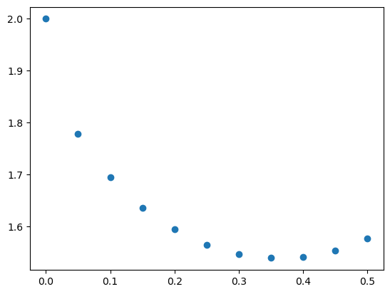

```python
# convert list to numpy array right away
t_vals = np.array( [0, 0.05, 0.1, 0.15, 0.2, 0.25, 0.3, 0.35, 0.4, 0.45, 0.5] )

# Evaluate function and create new array
g_of_t = np.exp(t_vals**2) - np.sqrt(t_vals) + 1

# Use plt.scatter to create scatter plot
plt.scatter(x = t_vals, y = g_of_t)
plt.show()
```

# Exercises

#### **1a)** Below are two lists containing the "Song of the Year" from the 2018-2021 Grammy Awards, and the winning songs for 2022-2025.

#### Concatenate the two lists to create a new list "songs_2018_2025"

```python
# Note: you are allowed to continue on the next line in the middle of a list

songs_2018_2021 = ["That's What I Like (Bruno Mars)", "This Is America (Childish Gambino)",
    "Bad Guy (Billie Eilish)", "I Can't Breathe (H.E.R.)"]

songs_2022_2025 = ["Leave the Door Open (Silk Sonic)", "Just Like That (Bonnie Raitt)",
    "What Was I Made For? (Billie Eilish)", "Not Like Us (Kendrick Lamar)"]

# SOLUTION

songs_2018_2025 = songs_2018_2021 + songs_2022_2025

print(songs_2018_2025)
```

```
["That's What I Like (Bruno Mars)", 'This Is America (Childish Gambino)', 'Bad Guy (Billie Eilish)', "I Can't Breathe (H.E.R.)", 'Leave the Door Open (Silk Sonic)', 'Just Like That (Bonnie Raitt)', 'What Was I Made For? (Billie Eilish)', 'Not Like Us (Kendrick Lamar)']
```

#### **1b)** The Song of the Year for the 2026 Grammy Awards was "Wildflower (Billie Eilish)" Using the list you created above, create a list of all Song of the Year winners from 2018 to 2026.

```python
# SOLUTION

songs_2018_2026 = songs_2018_2025 + ["Wildflower (Billie Eilish)"]

print(songs_2018_2026)
```

```
["That's What I Like (Bruno Mars)", 'This Is America (Childish Gambino)', 'Bad Guy (Billie Eilish)', "I Can't Breathe (H.E.R.)", 'Leave the Door Open (Silk Sonic)', 'Just Like That (Bonnie Raitt)', 'What Was I Made For? (Billie Eilish)', 'Not Like Us (Kendrick Lamar)', 'Wildflower (Billie Eilish)']
```

#### **1c)** Out of the 9 songs in the list create above, choose your favorite (or choose the one you hate the least). Print the name of the song by extracting the appropriate element of the list you created in part b).

```python
# SOLUTION

print(songs_2018_2026[2])
```

```
Bad Guy (Billie Eilish)
```

#### **2)** Poll the people sitting around you what their favorite color is (and poll yourself). Using two lists and `matplotlib.bar`, create a bar-plot describing the frequency of favorite colors in your region of the classroom.

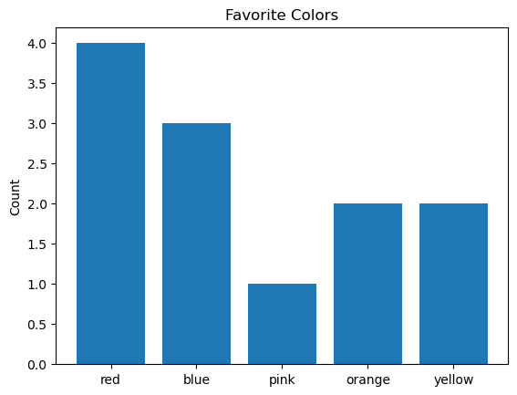

```python
# SOLUTION

# (made up example)

colors = ["red", "blue", "pink", "orange", "yellow"]
count = [4, 3, 1, 2, 2]



plt.bar(x = colors, height = count)
plt.title("Favorite Colors")
plt.ylabel("Count")
plt.show()
```

#### **3a)** How should we calculate the following in Python, using the numbers `27`, `12`, and `3`?

$$ \frac{27}{12 - 3} = \frac{27}{9} = 3$$

#### Compute this expression in the cell below

```python
# Calculate the expression above using the numbers 27, 12, 3
# Print the value -- you should get the number 3

# SOLUTION

val = 27 / (12 - 3)

print(val)
```

```
3.0
```

#### **3b)** How should we calculate the following in Python, using the numbers `5`, `3`, and `2`?

$$ (5 + 3)\cdot 2 = 8 \cdot 2 = 16$$

#### Compute this expression in the cell below

```python
# Calculate the expression above using the numbers 5, 3, 2
# Print the value -- you should get the number 16

# SOLUTION

val = (5 + 3) * 2

print(val)
```

```
16
```

#### **3c)** How should we calculate the following in Python, using the numbers `5`, `4`, `3`, and `2`?

$$ 5\cdot 3 + 2\cdot 4 = 15 + 8 = 23$$

#### Compute this expression in the cell below

```python
# Calculate the expression above using the numbers 5, 4, 3, 2
# Print the value -- you should get the number 23
# CHECK: Are parentheses necessary for this expression?

# SOLUTION

val = 5 * 3 + 2 * 4

# no parentheses are necessary!

print(val)
```

```
23
```

#### **3d)** How should we calculate the following in Python, using the numbers `5`, `4`, `3`, and `2`?

$$ \frac{(5 + 3)\cdot 2}{4} = \frac{16}{4} = 4$$

#### Compute this expression in the cell below

```python
# Calculate the expression above using the numbers 5, 4, 3, 2
# Print the value -- you should get the number 4
# CHECK: Are *two pairs* of parentheses are actually necessary?

# SOLUTION

val = (5 + 3) * 2 / 4

# only need ONE pair of parentheses

print(val)
```

```
4.0
```

#### **4)** Using NumPy, do the following:

- Define a variable $x = 0.5$
- Compute the value of $\pi x^2$ (ensure it prints to the screen)
- Compute the value of $\dfrac{1}{\sqrt{2\pi}}\mathrm{e}^{-x^2}$ (print to the screen)
- Compute the value of $\ln\big(\dfrac{2x + 1}{x + 2}\big)$ (print to the screen)

**Note**: Feel free to break up the computation into steps and define intermediate variables in order to make the code cleaner.

For example, for the final expression, you might find it convenient to create an additional variable $z = \dfrac{2x + 1}{x + 2}$

```python
# SOLUTION

x = 0.5

val_1 = np.pi * x**2

val_2 = np.exp(-x**2) / np.sqrt(2 * np.pi)

val_3_one_line = np.log((2*x + 1) / (x + 2))

numerator = 2*x + 1
denominator = x + 2

val_3 = np.log(numerator / denominator)

print(val_1)
print(val_2)
print(val_3_one_line)
print(val_3)
```

```
0.7853981633974483
0.3106965603769278
-0.2231435513142097
-0.2231435513142097
```

#### **5)** The code cell below defines two vectors

$a = \begin{pmatrix} a_1\\a_2\\a_3\end{pmatrix},\quad b = \begin{pmatrix} b_1\\b_2\\b_3\end{pmatrix}$

#### In one line of code each, define the following vectors:

$c = \begin{pmatrix} a_1\cdot b_1\\ a_2 \cdot b_2 \\ a_3 \cdot b_3 \end{pmatrix}, \quad d = \begin{pmatrix} 5 - a_1\\ 5 - a_2 \\ 5 - a_3 \end{pmatrix},\quad e = \begin{pmatrix} (a_1 - b_1)/2 \\ (a_2 - b_2)/2 \\ (a_3 - b_3)/2\end{pmatrix}$

$f = \begin{pmatrix} b_1^{a_1}\\ b_2^{a_2} \\ b_3^{a_3} \end{pmatrix},\quad g = \begin{pmatrix} 2^{a_1}\\ 2^{a_2} \\ 2^{a_3}\end{pmatrix},\quad h = \begin{pmatrix} \mathrm{e}^{a_1 + b_1} \\ \mathrm{e}^{a_2 + b_2} \\ \mathrm{e}^{a_3 + b_3} \end{pmatrix}$

#### (Try to extend the vector operations you saw above)

```python
a = np.array([2, 1.2, 3.4])
b = np.array([2.2, -3, 10.01])

# fill in the correct code below
c = a * b
d = 5 - a
e = (a - b)/2
f = b**a
g = 2**a
h = np.exp(a + b)

# note that there is a warning, NOT an error when calculating f
```

```
/var/folders/6y/3fspf4yj07l356wmy5nqj83h0000gq/T/ipykernel_94875/2952514965.py:8: RuntimeWarning: invalid value encountered in power
  f = b**a
```

#### We saw a message saying "RuntimeWarning: invalid value encountered in power f = b**a".

#### This isn't an error message, it's a warning message. Let's print the variable `f` to try and see what's going on

```python
print(f)
print(f[1])


# The value of f[1] is "nan". This stands for "not a number"

# This is because b[1] ** a[1] calculates (-3) ** 1.2,
# which means (-3) raised to the power 1.2

# By rules of exponentiation, (-3)^1.2 = (-1 * 3)^(1.2) = (-1)^1.2 * 3^1.2,
# but (-1)^1.2 is not defined for floating point numbers.
# So it's "not a number"

# Lesson: be careful not to blindly apply math operations,
# unless your code can handle cases where "nan" appears!
```

```
[   4.84                 nan 2520.43709866]
nan
```

#### **6)** In the cell below, two arrays are created:

$a = \begin{pmatrix} a_1\\a_2\\a_3\\a_4\end{pmatrix},\quad b = \begin{pmatrix} b_1\\b_2\\b_3\\b_4\end{pmatrix}$

### Define a new array

$c = \begin{pmatrix} a_1/b_1\\ a_2/b_2\\ a_3/b_3\\a_4/b_4\end{pmatrix}$

### and print its value to the screen. What do you see?

```python
# your code here
a = np.array([0, 1.0, np.pi, np.cos(np.pi/12)])
b = np.array([0, 2.0, 4, 0])

# your code here
c = a/b
print(c)
```

```
[       nan 0.5        0.78539816        inf]
```

```python
# We got two more warning messages above.

# 0/0 is not defined. --> "not a number"
print(c[0])

# cos(pi/12)/0 is not defined, because division by zero is not defined.
# HOWEVER, the creators of floating-point arithmetic decided that when you divide a postive
# number by zero, the result should be infinity.
print(c[3])

# If you see output containing "inf" or "nan", you most likely divided by zero somewhere
# (or you raised a negative number to a fractional power)
```

[output not shown]

[output not shown]

```
nan
inf
```

#### **7)** Using NumPy arrays, create a scatter plot of the function

$$q(x) = \sin(\pi x) + 1$$

#### at a set of points in the interval $0 \leq x \leq 2$. (You are free to choose which points are actually used)

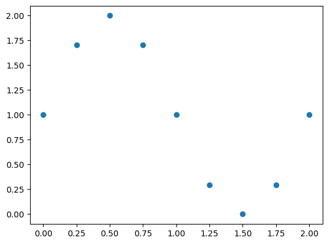

```python
# SOLUTION

# I chose points evenly-spaced by 0.25
x = np.array([0, 0.25, 0.5, 0.75, 1, 1.25, 1.5, 1.75, 2])

q = np.sin(np.pi*x) + 1

plt.scatter(x = x, y = q)
plt.show()
```

#### **8)** Using NumPy arrays, create a scatter plot of the function $f(g(t))$, where

$$ f(x) = x^2 - 5x + 2 $$

$$ g(t) = \sin(t + 3) $$

#### at a set of points in the interval $\sout{2\pi \leq x \leq 4\pi}$ $2\pi \leq t \leq 4\pi$ (You are free to choose which points are actually used)

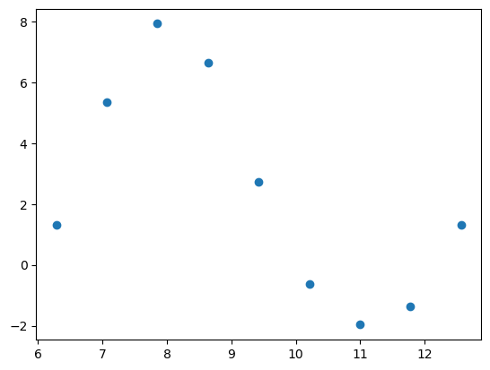

```python
# SOLUTION

# first I create evenly spaced points between 2 and 4 (with 0.25 spacing)
u_vals = np.array([2, 2.25, 2.5, 2.75, 3, 3.25, 3.5, 3.75, 4])

# Then I multiply by π to get points between 2π and 4π
t_vals = np.pi * u_vals


# Or we could have done it in one line
t_vals_one_line = np.pi * np.array([2, 2.25, 2.5, 2.75, 3, 3.25, 3.5, 3.75, 4])

# evaluate the composite function in two steps
g_vals = np.sin(t_vals + 3)

f_vals = g_vals**2 - 5*g_vals + 2

# create the plot
plt.scatter(x = t_vals, y = f_vals)
plt.show()
```

### **9)** Compute some simple statistics for the following set of numbers:

$$ 4.2,\ 1.2,\ 11.45,\ -2,\ 0,\ 9,\ 3.3,\ 2\pi $$

In particular, compute:

- the mean
- the standard deviation
- the median
- the maximum
- the minimum

Use the built-in NumPy functions: `numpy.mean`, `numpy.std`, `numpy.median`, `numpy.max`, `numpy.min`

```python
# your code here

c_vec = np.array([4.2, 1.2, 11.45, -2, 0, 9, 3.3, 2*np.pi])


print("mean:", np.mean(c_vec))
print("standard deviation:", np.std(c_vec))
print("median:", np.median(c_vec))
print("maximum:", np.max(c_vec))
print("minimum:", np.min(c_vec))
```

```
mean: 4.179148163397448
standard deviation: 4.269494739300707
median: 3.75
maximum: 11.45
minimum: -2.0
```